# Reproducible Research and ECON 407 Problem Sets

From [Wikipedia](https://en.wikipedia.org/wiki/Reproducibility#%20Reproducible_research), reproducible research is defined as:

> The term reproducible research refers to the idea that the ultimate product of academic research is the paper **along with** the full computational environment used to produce the results in the paper such as the code, data, etc. that can be used to reproduce the results and create new work based on the research.

The reproducible research movement (especially for the statistical sciences) takes this a step further by advocating for dynamic documents. The idea is that a researcher should provide a file (the dynamic document) that can execute the statistical analysis, generate figures, and contains accompanying text narrative. This file can be executed to produce the **academic paper**. The researcher shares this file with other researchers rather than the only the paper. It is my view that within 20 years nearly every scientific journal in applied statistics will require this approach.

This document shows how to use `RMarkdown` and markdown syntax. The idea behind `RMarkdown` is that you share your research by sharing your program file. This file performs the full suite of statistical analysis and can produce the pdf or MS Word document describing your analysis. You will use this workflow for producing pdf or word documents for class assignments.

For every problem set, you will turn in

- The `Rmarkdown` file containing all commands and written text that produces your problem set responses. [the `R` file]
- A hardcopy of the pdf version produced after running your do file [the hardcopy]
- The only exception to this rule is for questions involving proofs or other equation heavy assigments where handwritten responses can be attached to the hardcopy problem set response.

# Some Features of `RMarkdown`

RMarkdown allows for most features of [Markdown](https://daringfireball.net/projects/markdown/syntax), which is a liteweight and readable **text-based** language that allows files to be easily converted to nice looking pdf, html, or even word documents. Some features you will likely want to use:

- Equations and Math Notation using latex math
- Headers
- Emphasizing text (bold and italics)
- Numeric and bulletted lists
- Turning stata output on and off

# A simple example analysis using `Rmarkdown`

Below we’ll be modeling the following regression equation for cars back in the day:

$$price_i = \beta_0 + \beta_1 mpg_i + \beta_2 foreign_i + \epsilon_i$$

## Load Data and Summarize

```r
auto = read.csv("http://rlhick.people.wm.edu/econ407/data/auto.csv")
summary(auto)
```

```
##           make        price            mpg            rep78
##  AMC Concord: 1   Min.   : 3291   Min.   :12.00   Min.   :1.000
##  AMC Pacer  : 1   1st Qu.: 4220   1st Qu.:18.00   1st Qu.:3.000
##  AMC Spirit : 1   Median : 5006   Median :20.00   Median :3.000
##  Audi 5000  : 1   Mean   : 6165   Mean   :21.30   Mean   :3.406
##  Audi Fox   : 1   3rd Qu.: 6332   3rd Qu.:24.75   3rd Qu.:4.000
##  BMW 320i   : 1   Max.   :15906   Max.   :41.00   Max.   :5.000
##  (Other)    :68                                   NA's   :5
##     headroom         trunk           weight         length
##  Min.   :1.500   Min.   : 5.00   Min.   :1760   Min.   :142.0
##  1st Qu.:2.500   1st Qu.:10.25   1st Qu.:2250   1st Qu.:170.0
##  Median :3.000   Median :14.00   Median :3190   Median :192.5
##  Mean   :2.993   Mean   :13.76   Mean   :3019   Mean   :187.9
##  3rd Qu.:3.500   3rd Qu.:16.75   3rd Qu.:3600   3rd Qu.:203.8
##  Max.   :5.000   Max.   :23.00   Max.   :4840   Max.   :233.0
##
##       turn        displacement     gear_ratio        foreign
##  Min.   :31.00   Min.   : 79.0   Min.   :2.190   Domestic:52
##  1st Qu.:36.00   1st Qu.:119.0   1st Qu.:2.730   Foreign :22
##  Median :40.00   Median :196.0   Median :2.955
##  Mean   :39.65   Mean   :197.3   Mean   :3.015
##  3rd Qu.:43.00   3rd Qu.:245.2   3rd Qu.:3.353
##  Max.   :51.00   Max.   :425.0   Max.   :3.890
##
```

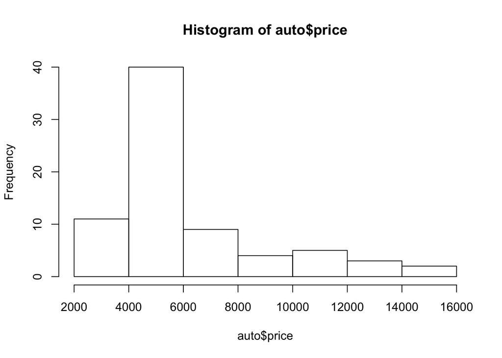

```r
hist(auto$price)
```

### Regression Model

Here are the regression results:

```r
summary(lm(price~mpg+foreign,data=auto))
```

```
##
## Call:
## lm(formula = price ~ mpg + foreign, data = auto)
##
## Residuals:
##     Min      1Q  Median      3Q     Max
## -3198.6 -1601.3  -816.9   858.6 10178.7
##
## Coefficients:
##                Estimate Std. Error t value Pr(>|t|)
## (Intercept)    11905.42    1158.63  10.275 1.09e-15 ***
## mpg             -294.20      55.69  -5.283 1.33e-06 ***
## foreignForeign  1767.29     700.16   2.524   0.0138 *
## ---
## Signif. codes:  0 '***' 0.001 '**' 0.01 '*' 0.05 '.' 0.1 ' ' 1
##
## Residual standard error: 2531 on 71 degrees of freedom
## Multiple R-squared:  0.2838, Adjusted R-squared:  0.2637
## F-statistic: 14.07 on 2 and 71 DF,  p-value: 7.124e-06
```

### Discussion

Looks like back in the day, foreign cars sell for more!

## Document Source

This document was written and generated entirely within `R`.